# Foodborne Chicago Survey Analysis

Cory Nissen

12/31/2014

### Introduction

Within 7 months of launching [Foodborne Chicago](https://www.foodbornechicago.org/) with the help of the [Smart Chicago Collaborative](http://www.smartchicagocollaborative.org/) and the Chicago Health Department back in April of 2013, we noticed that many of the complaints generated through the system were on the north side of the city, with very few coming from the south side. In November 2013, we created [several maps](https://github.com/corynissen/foodborne_chicago_report_map/commit/b1d0559f265b6a708da3480a8d30e096e609bc63) of the submissions to visualize this phenomenon. The [Knight foundation](http://www.knightfoundation.org/) helped us with funding via their [prototype fund](http://www.knightfoundation.org/blogs/knightblog/2014/1/22/testable-moment-for-media-innovation/) to investigate reasons why this might be. We used some of those funds to run a survey of Chicago residents.

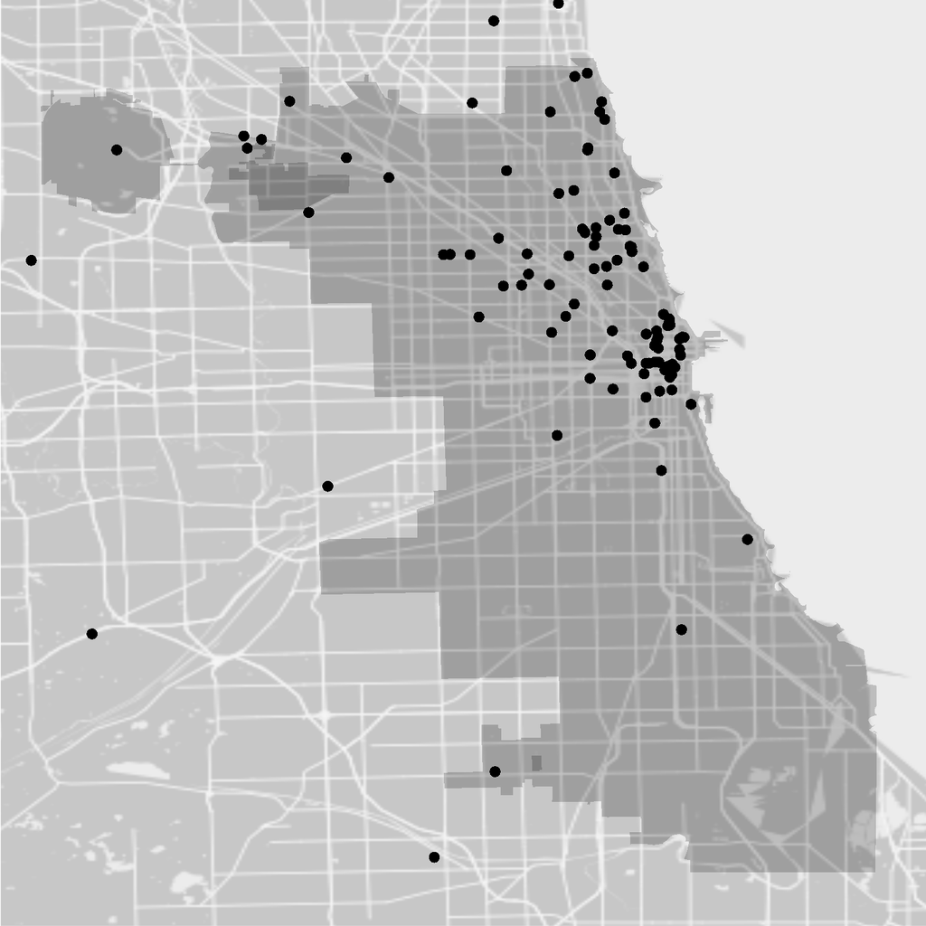

### Survey Set Up

The survey was run on Chicago residents that have used [Twitter](http://www.twitter.com) recently. It was administered online by [SSI](http://www.surveysampling.com/) from December 11, 2014 to December 19, 2014. There were 6 screener questions and 16 regular questions on [the survey](https://github.com/corynissen/foodborne_survey/blob/master/foodborne_chicago_final_survey.docx). We were aiming for a good mix of north side and south side residents. We had 91 completed surveys, with 56 on the north side and 35 on the south side. For the purposes of our analysis, north side is defined as north of the line that the northern edge of zip codes 60623, 60608, 60616 create across the city. Zip codes 60623, 60608, 60616 and those to the south are considered south side. Much of the analysis to follow will focus on this somewhat arbitrary line.

### Profile of respondents

#### Gender

|  | Frequency |
| --- | --- |
| Female | 54.9% |
| Male | 45.1% |

#### Age

|  | Frequency |
| --- | --- |
| 18-24 years | 19.8% |
| 25-34 years | 35.2% |
| 35-44 years | 25.3% |
| 45-54 years | 12.1% |
| 55-64 years | 6.6% |
| 65 and up | 1.1% |

#### How often do you check Twitter?

|  | Frequency |
| --- | --- |
| Daily | 67% |
| A few times per week | 27.5% |
| Once a week | 3.3% |
| Every 2-3 weeks | 2.2% |

#### What is the primary way that you connect to the Internet?

|  | Frequency |
| --- | --- |
| Broadband at home (Cable, DSL, etc) | 59.3% |
| Phone plan with data included | 36.3% |
| Public WiFi | 4.4% |

#### Have you ever been a victim of food poisoning?

|  | Frequency |
| --- | --- |
| Yes | 31.9% |
| No | 68.1% |

|  | Yes | No |
| --- | --- | --- |
| North | 41.1% | 58.9% |
| South | 17.1% | 82.9% |

#### Have you ever reported a case of food poisoning to the Chicago health department?

|  | Frequency |
| --- | --- |
| NA | 68.1% |
| Yes | 8.8% |
| No | 23.1% |

|  | NA | Yes | No |
| --- | --- | --- | --- |
| North | 58.9% | 12.5% | 28.6% |
| South | 82.9% | 2.9% | 14.3% |

#### If you were to report a case of food poisoning to the Chicago health department, how confident are you that your report would be followed up on?

|  | Frequency |
| --- | --- |
| 1 Not at all confident | 3.3% |
| 2 | 4.4% |
| 3 | 4.4% |
| 4 | 4.4% |
| 5 | 13.2% |
| 6 | 12.1% |
| 7 | 6.6% |
| 8 | 23.1% |
| 9 | 19.8% |
| 10 Extremely confident | 8.8% |

#### To what extent do you agree or disagree with the following statement: “In the event that you or somebody in your family became ill after eating at a restaurant, it is your civic duty to report the illness to the authorities.”

|  | Frequency |
| --- | --- |
| Strongly disagree | 1.1% |
| Disagree | 4.4% |
| Neither agree nor disagree | 16.5% |
| Agree | 35.2% |
| Strongly agree | 42.9% |

#### To what extent do you agree or disagree with the following statement: “I am okay with a person or an organization that I do not follow on Twitter replying to a tweet that I send out.”

|  | Frequency |
| --- | --- |
| Strongly disagree | 3.3% |
| Disagree | 7.7% |
| Neither agree nor disagree | 26.4% |
| Agree | 44% |
| Strongly agree | 16.5% |
| Not sure | 2.2% |

### What does it mean?

The purpose of this survey was to explore why there were more food poisoning reports through the Foodborne Chicago app on the north side of the city compared to the south side. We wanted to ensure that we had covered our bases in terms of ensuring that all communities felt comfortable using the application and that the opportunity existed for the entire city to take advantage of our app. The results from our CUT group informed design and content changes to our website and form. The CUT group testing suggested that folks were not opposed to us contacting them via twitter, and in some cases inserting ourselves into their rather intimate conversation, with one caveat; we had to be “official”. We gained approval from the Chicago Department of Public Health to include their logo on our website. Foodborne Chicago still faces a challenge of engaging community leaders in order to get the word out and become accepted as a trusted member of the various twitter circles that exist in the city.

41% of the north side residents surveyed had been victim of food poisoning, compared with just 17% of the south side residents. Thus, having more complaints from the north side should not be surprising. Now, exploring the cause of this phenomenon may be worthwhile, but is outside of the scope of this work. Is this a case of mis-diagnosis on the north side or lack of diagnosis on the south side? It could be that since there are more restaurants on the north side, we should expect that more food poisonings occur there. Regardless of the cause, it’s important to note that we might expect more reports from the north side given that they seemingly suffer from food poisoning at a higher rate.

The survey participants did not have an issue with us contacting them through twitter. This aligned with what we heard at the CUT group. Foodborne Chicago, and other twitter API users are experiencing an issue with collecting tweets within a given geographical area. It’s a known issue on twitter’s end, and they are working to fix it. For the time being, our ability to use twitter for public outreach has all but been cut off.

Next steps will include a community outreach effort to identify ways to interact on social media and be part of the community network.

### Raw Data, Survey, and Supporting Documentation

The original survey can be found as a docx file here. The data file from the survey vendor as a xlsx file is here. I’ve tidied up the data a bit, created labels, and created an Rdata file for further analysis.